# ds8-project

Raju Varghese

06/18/2015

# Project: Practical Machine Learning course

## Aim

This is the project report for the Coursera Data Science course **Practical Machine Learning**. The [project](https://class.coursera.org/predmachlearn-015/human_grading/view/courses/973550/assessments/4/submissions) requires students to analyze a CSV file (ie the training set) containing data from sensors placed on 6 persons who were then asked to perform barbell lifts (original source: [Human Activity Research](http://groupware.les.inf.puc-rio.br/har) at a university in Rio de Janiero, Brazil). The aim of the course is to use similar sensor data (ie the test set) to predict the activity and to submit that for evaluation by the course organizers.

## Introduction

As there are many machine learning algorithms the first step is to find the appropriate one for the job at hand. It is obvious that this is a job for supervised learning as there is a training set with labels that have been assigned. Looking through the data cursorily as well as reading through the project description one leads one to the conclusion that this is a classification problem: the expected result is the labeling of an activity. Therefore, it is *not* a regression problem where a continuous value is to be predicted. Of the methods at ones disposal the Random Forest method has been cited often in current literature as a good one for classification. As will be seen later, I was more than satisfied with that choice.

## Data Input and Exploration

The project page has the URLs for the [training](https://d396qusza40orc.cloudfront.net/predmachlearn/pml-training.csv) and [testing](https://d396qusza40orc.cloudfront.net/predmachlearn/pml-testing.csv) data. These were downloaded to the machine and stored on the disk.

```r
f <- read.csv ("pml-training.csv")
dim (f)
```

```
## [1] 19622   160
```

Looking through the data one can see that there are many columns with blanks, NA or cells of the form “#DIV/0!”. With *summary* these columns are made plain. Further, the initial columns are not sensor data but those that identify where it came from or the time they were collected. For modelling these are useless.

```r
summary (f)
```

[output not shown]

## Data Preparation

The two types of columns mentioned above are listed below in the variable *excl*.

```r
excl <- c("X", "user_name", "raw_timestamp_part_1", "raw_timestamp_part_2", "cvtd_timestamp",
          "new_window", "num_window",
          "kurtosis_yaw_belt", "skewness_yaw_belt", "kurtosis_yaw_dumbbell", "skewness_yaw_dumbbell",
          "amplitude_yaw_forearm", "skewness_yaw_forearm", "kurtosis_yaw_forearm", "amplitude_yaw_dumbbell",
          "amplitude_yaw_dumbbell", "kurtosis_picth_arm", "kurtosis_yaw_arm", "skewness_roll_arm",
          "skewness_pitch_arm", "skewness_yaw_arm", "kurtosis_roll_belt", "kurtosis_picth_belt",
          "skewness_roll_belt", "skewness_roll_belt.1", "max_yaw_belt", "max_roll_belt, max_picth_belt",
          "max_yaw_belt", "min_roll_belt", "min_pitch_belt, min_yaw_belt", "amplitude_roll_belt",
          "amplitude_pitch_belt", "amplitude_yaw_belt", "var_total_accel_belt", "avg_roll_belt",
          "stddev_roll_belt", "var_roll_belt", "avg_pitch_belt", "stddev_pitch_belt",
          "var_pitch_belt", "avg_yaw_belt", "stddev_yaw_belt, var_yaw_belt", "var_accel_arm",
          "avg_roll_arm", "stddev_roll_arm", "var_roll_arm", "avg_pitch_arm", "stddev_pitch_arm",
          "var_pitch_arm", "avg_yaw_arm", "stddev_yaw_arm", "var_yaw_arm", "kurtosis_roll_arm",
          "max_roll_arm", "max_picth_arm", "max_yaw_arm", "min_roll_arm", "min_pitch_arm",
          "min_yaw_arm", "amplitude_roll_arm", "amplitude_pitch_arm", "amplitude_yaw_arm",
          "kurtosis_roll_dumbbell", "kurtosis_picth_dumbbell", "skewness_roll_dumbbell",
          "skewness_pitch_dumbbell", "max_roll_dumbbell", "max_picth_dumbbell", "max_yaw_dumbbell",
          "min_roll_dumbbell", "min_pitch_dumbbell", "min_yaw_dumbbell", "amplitude_roll_dumbbell",
          "amplitude_pitch_dumbbell", "var_accel_dumbbell", "avg_roll_dumbbell", "stddev_roll_dumbbell",
          "var_roll_dumbbell", "avg_pitch_dumbbell", "stddev_pitch_dumbbell", "var_pitch_dumbbell",
          "avg_yaw_dumbbell", "stddev_yaw_dumbbell", "var_yaw_dumbbell", "kurtosis_roll_forearm",
          "kurtosis_picth_forearm", "skewness_roll_forearm", "skewness_pitch_forearm", "max_roll_forearm",
          "max_yaw_forearm", "min_roll_forearm", "min_pitch_forearm", "min_yaw_forearm",
          "amplitude_roll_forearm", "amplitude_pitch_forearm", "var_accel_forearm", "avg_roll_forearm",
          "stddev_roll_forearm", "var_roll_forearm", "avg_pitch_forearm", "stddev_pitch_forearm",
          "var_pitch_forearm", "avg_yaw_forearm", "stddev_yaw_forearm", "var_yaw_forearm",
          "stddev_yaw_belt", "max_picth_forearm", "max_roll_belt", "max_picth_belt", "min_pitch_belt",
          "min_yaw_belt", "var_yaw_belt")

exclVars <- names(f) %in% excl
fClean <- f [!exclVars]
```

```r
library (caret)
library (randomForest)
library (doParallel)
set.seed (42)
```

```r
inTrain <- createDataPartition (fClean$classe, p=0.50, list=F)
trainingSamples = fClean [ inTrain,]
validationSamples = fClean [-inTrain,]
```

NOTE: the original training data that was downloaded is split into two that are called trainingSamples and validationSamples.

## Modelling

The training data set is now going to be put through the *random forest* function where several decision trees will be evaluated. The *training control* sub-function specifies 5 fold *cross validation*. To speed up the overall process the code below will run in parallel on all the CPU cores of the workstation. On my machine with 4 CPU cores, this chunk of code takes 220 seconds.

```r
cl <- makeCluster(detectCores())
registerDoParallel(cl)
model<-train (classe ~ ., data=trainingSamples, method="rf",
              trControl=trainControl (method="cv", number=5),
              prox=T, importance=T, allowParallel=T)
stopCluster(cl)
model
```

```
## Random Forest
##
## 9812 samples
##   52 predictors
##    5 classes: 'A', 'B', 'C', 'D', 'E'
##
## No pre-processing
## Resampling: Cross-Validated (5 fold)
##
## Summary of sample sizes: 7848, 7850, 7851, 7849, 7850
##
## Resampling results across tuning parameters:
##
##   mtry  Accuracy   Kappa      Accuracy SD  Kappa SD
##    2    0.9841000  0.9798812  0.003257335  0.004122614
##   27    0.9855266  0.9816881  0.003099292  0.003923915
##   52    0.9782904  0.9725313  0.003625498  0.004590005
##
## Accuracy was used to select the optimal model using  the largest value.
## The final value used for the model was mtry = 27.
```

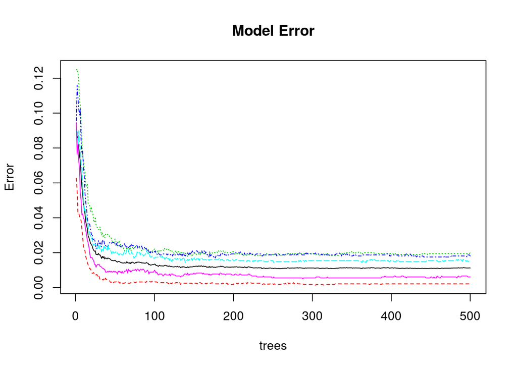

```r
plot (model$finalModel, main="Model Error")
```

As a matter of interest, the most important variables are shown below.

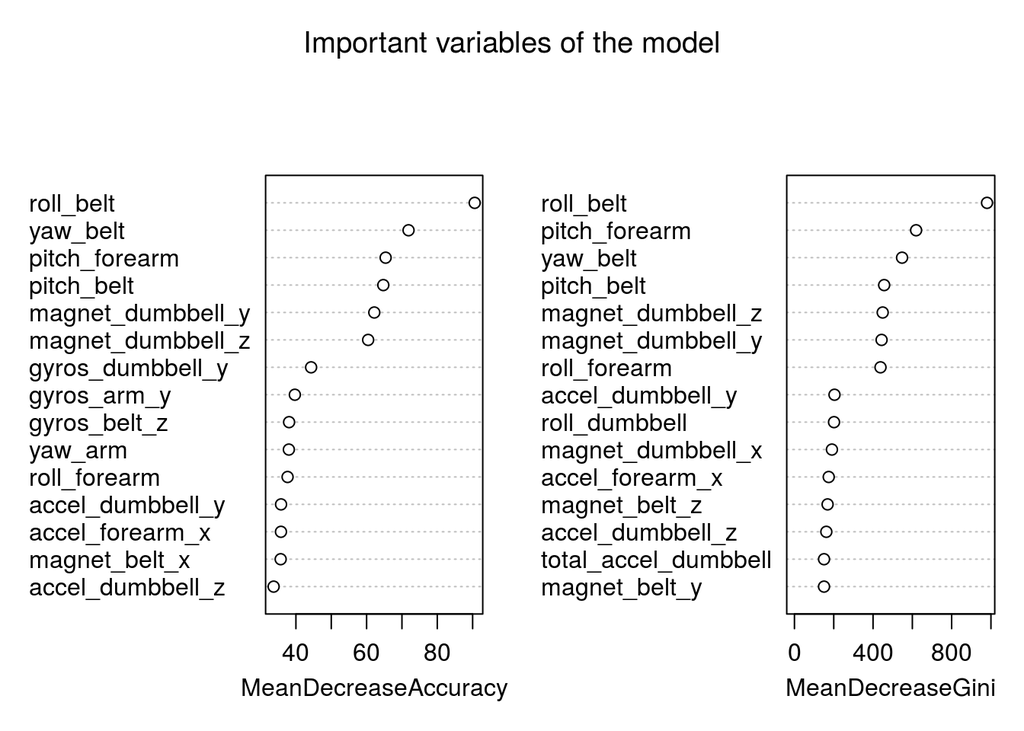

```r
varImpPlot (model$finalModel, main="Important variables of the model", n.var=15)
```

## Prediction and Validation

Based on the model above we get to the final stage, prediction.

```r
res <- predict (model, validationSamples)
confusionMatrix (res, validationSamples [, c ("classe")])
```

```
## Confusion Matrix and Statistics
##
##           Reference
## Prediction    A    B    C    D    E
##          A 2787   15    0    0    0
##          B    3 1875   12    1    2
##          C    0    5 1694   20    2
##          D    0    3    5 1585    3
##          E    0    0    0    2 1796
##
## Overall Statistics
##
##                Accuracy : 0.9926
##                  95% CI : (0.9907, 0.9942)
##     No Information Rate : 0.2844
##     P-Value [Acc > NIR] : < 2.2e-16
##
##                   Kappa : 0.9906
##  Mcnemar's Test P-Value : NA
##
## Statistics by Class:
##
##                      Class: A Class: B Class: C Class: D Class: E
## Sensitivity            0.9989   0.9879   0.9901   0.9857   0.9961
## Specificity            0.9979   0.9977   0.9967   0.9987   0.9998
## Pos Pred Value         0.9946   0.9905   0.9843   0.9931   0.9989
## Neg Pred Value         0.9996   0.9971   0.9979   0.9972   0.9991
## Prevalence             0.2844   0.1935   0.1744   0.1639   0.1838
## Detection Rate         0.2841   0.1911   0.1727   0.1616   0.1831
## Detection Prevalence   0.2856   0.1930   0.1754   0.1627   0.1833
## Balanced Accuracy      0.9984   0.9928   0.9934   0.9922   0.9979
```

## Result Submission

As I am satisfied with the model I can now run it on the test data provided.

```r
test <- read.csv ("pml-testing.csv")
test.result <- predict (model, test)

pml_write_files = function (x) {
  n = length (x)
  for (i in 1:n) {
    filename = paste0 ("problem_id_", i, ".txt")
    path = file.path ("../answers", filename)
    write.table(x[i],file=path, quote=F, row.names=F, col.names=F)
  }
}
pml_write_files (test.result)
```

## Conclusion

Though the time needed for modelling is high the accuracy of the prediction is high as well. There was not enough time to figure out how to evaluate different resampling algorithms. Frankly, I am astounded and pleased with the accuracy.